# ICT_LIS_661_Final_Project

# Problem Statement [5 points]

> Describe the data problem(s) you are addressing and what research questions related to the problem(s) you are asking. [3 points]

Data Problem(s): Do games “improve” overall as the years advance?

Research Question: Does the year in which a video game was released or created affect its rating?

> Provide some contextual information related to the problem(s). [2 points]

If I were a new “gamer” and wanted to play the “best games,” I would want to know if the older generations were better than the new ones. Understanding this question will put into perspective whether time has improved or worsened the quality of games overall. Spending endless hours playing non-enjoyable games seems like a waste of time, and through this analysis, we will uncover if it is worth it to stick with the newer or older generations. There are many gamers out there who are always asking the age-old question of what is the best game, and by narrowing it down to the years in which a game was released, can help them decide what to play next. Another aspect to consider is the technology used in the development of the game. Technology is always advancing, and with its help, video games may improve or deteriorate in the process. This study’s data set will include eight variables from IMDB-rated video games. These variables were chosen because they encompass all aspects of each video game. While the data has been collected, it is not organized in a way that researchers could look at it and interpret it at a glance.

# Data Description, Preparation, and Exploration [10 points]

> In the code chunk below, run all the code necessary to respond to the questions below; please note that this should include at least one visualization! [2 points]

```r
library(tidyverse)
library(readr)
library(moderndive)
library(skimr)
library(here)
```

```r
library(dplyr)
library(infer)
library(moderndive)
library(ggplot2movies)
library(tidyverse)
library(here)
library(ggplot2)

game <- read_csv(here("project_final","imdb_video_game_rating.csv"))
game$year <- as.integer(game$year)
class(game)
```

```
## [1] "spec_tbl_df" "tbl_df"      "tbl"         "data.frame"
```

```r
game
```

```
## # A tibble: 12,635 × 8
##    index title                             year genre rating votes direc…¹ plot
##    <dbl> <chr>                            <int> <chr>  <dbl> <dbl> <chr>   <chr>
##  1     0 The Last of Us: Part I            2022 Acti…    9.8   601 Matthe… Expe…
##  2     1 Red Dead Redemption II            2018 Acti…    9.7 36441 Missing Amid…
##  3     2 The Witcher 3: Wild Hunt - Bloo…  2016 Acti…    9.7  7610 Konrad… Gera…
##  4     3 The Witcher 3: Wild Hunt          2015 Acti…    9.7 26328 Konrad… A mo…
##  5     4 The Last of Us                    2013 Acti…    9.7 61103 Neil D… In a…
##  6     5 Mass Effect: Legendary Edition    2021 Acti…    9.7  1628 Casey … A co…
##  7     6 God of War                        2018 Acti…    9.6 26507 Cory B… Afte…
##  8     7 Persona 5 Royal                   2019 Acti…    9.6  1214 Daiki … A gr…
##  9     8 The Legend of Zelda: Ocarina of…  1998 Acti…    9.6  9576 Eiji A… A yo…
## 10     9 Metal Gear Solid                  1998 Acti…    9.6 11809 Hideo … A cr…
## # … with 12,625 more rows, and abbreviated variable name ¹directors
```

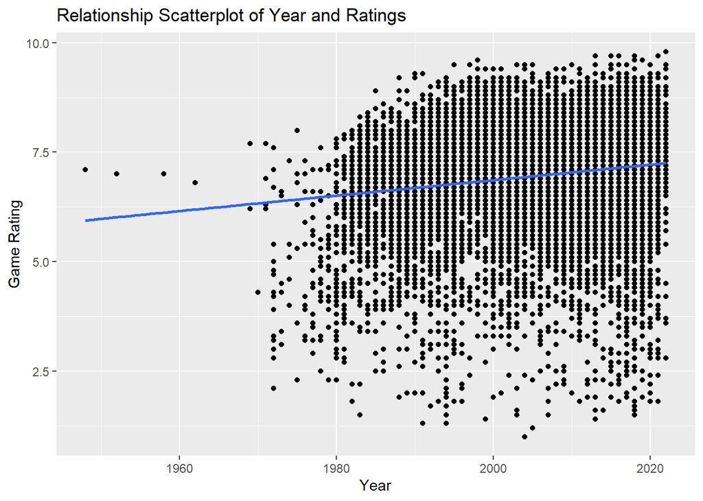

```r
#Loading and Exploring Our Data
#Selecting specific variables
game_reg <- game %>%
  select(year, rating)

#Graph
ggplot(game_reg, aes(x = year, y = rating)) +
  geom_point() +
  labs(x = "Year",
       y = "Game Rating",
       title = "Relationship Scatterplot of Year and Ratings")+
        geom_smooth(method = "lm", se = FALSE)
```

```r
#Descriptive Statistics

#Regression Table
# Fit regression model:
fit_model <- lm(rating ~ year, data = game_reg)
# Get regression table:
get_regression_table(fit_model)
```

```
## # A tibble: 2 × 7
##   term      estimate std_error statistic p_value lower_ci upper_ci
##   <chr>        <dbl>     <dbl>     <dbl>   <dbl>    <dbl>    <dbl>
## 1 intercept  -28.5       2.05      -13.9       0  -32.5     -24.5
## 2 year         0.018     0.001      17.3       0    0.016     0.02
```

```r
#R^2
summary(fit_model)
```

```
##
## Call:
## lm(formula = rating ~ year, data = game_reg)
##
## Residuals:
##     Min      1Q  Median      3Q     Max
## -5.9351 -0.6296  0.2057  0.8596  2.7710
##
## Coefficients:
##               Estimate Std. Error t value Pr(>|t|)
## (Intercept) -28.509404   2.050662  -13.90   <2e-16 ***
## year          0.017687   0.001023   17.29   <2e-16 ***
## ---
## Signif. codes:  0 '***' 0.001 '**' 0.01 '*' 0.05 '.' 0.1 ' ' 1
##
## Residual standard error: 1.241 on 12530 degrees of freedom
##   (103 observations deleted due to missingness)
## Multiple R-squared:  0.0233, Adjusted R-squared:  0.02322
## F-statistic: 298.9 on 1 and 12530 DF,  p-value: < 2.2e-16
```

```r
game_reg %>% skim()
```

Data summary

| Name | Piped data |
| --- | --- |
| Number of rows | 12635 |
| Number of columns | 2 |
| _______________________ |  |
| Column type frequency: |  |
| numeric | 2 |
| ________________________ |  |
| Group variables | None |

**Variable type: numeric**

| skim_variable | n_missing | complete_rate | mean | sd | p0 | p25 | p50 | p75 | p100 | hist |
| --- | --- | --- | --- | --- | --- | --- | --- | --- | --- | --- |
| year | 103 | 0.99 | 2004.63 | 10.84 | 1948 | 1997.0 | 2005.0 | 2014.0 | 2022.0 | ▁▁▃▇▇ |
| rating | 0 | 1.00 | 6.95 | 1.25 | 1 | 6.3 | 7.2 | 7.8 | 9.8 | ▁▁▂▇▂ |

```r
#cor()
game_reg %>% na.omit() %>%
  get_correlation(formula = year ~ rating)
```

```
## # A tibble: 1 × 1
##     cor
##   <dbl>
## 1 0.153
```

```r
glimpse(game_reg)
```

```
## Rows: 12,635
## Columns: 2
## $ year   <int> 2022, 2018, 2016, 2015, 2013, 2021, 2018, 2019, 1998, 1998, 201…
## $ rating <dbl> 9.8, 9.7, 9.7, 9.7, 9.7, 9.7, 9.6, 9.6, 9.6, 9.6, 9.5, 9.5, 9.5…
```

```r
summary(game_reg)
```

```
##       year          rating
##  Min.   :1948   Min.   :1.000
##  1st Qu.:1997   1st Qu.:6.300
##  Median :2005   Median :7.200
##  Mean   :2005   Mean   :6.945
##  3rd Qu.:2014   3rd Qu.:7.800
##  Max.   :2022   Max.   :9.800
##  NA's   :103
```

```r
str(game_reg)
```

```
## tibble [12,635 × 2] (S3: tbl_df/tbl/data.frame)
##  $ year  : int [1:12635] 2022 2018 2016 2015 2013 2021 2018 2019 1998 1998 ...
##  $ rating: num [1:12635] 9.8 9.7 9.7 9.7 9.7 9.7 9.6 9.6 9.6 9.6 ...
```

```r
game_rating_dis <- game_reg %>%
  summarize(mean_rating = mean(rating), median_rating = median(rating), Variance_rating = var(rating), standard_deviation_rating = sd(rating))
game_rating_dis
```

```
## # A tibble: 1 × 4
##   mean_rating median_rating Variance_rating standard_deviation_rating
##         <dbl>         <dbl>           <dbl>                     <dbl>
## 1        6.95           7.2            1.57                      1.25
```

> Explain how you imported and manipulated the data for analysis. [2 points]

When I imported the data, I used “read.csv” to read the file I had in the folder of the wording directory. I first had to change the year variable to numeric and omit any NA possibility. After that, I created another DF with only the year and rating variables that will be used in the line regression analyses. Once I had the desired DF, I created a graph using “ggplot2” and “gemo_smooth” to make a visual line regression analysis. Afterward, I created multiple descriptive statistic codes to give me all the information I could need. The information I produced told me the correlation coefficient, standard deviation, mean, median, variance, and multiple R squared.

> Provide the description of key variables and their descriptive statistics. What do these descriptive statistics tell you about the data? [2 points]

> Explain how you visualized the data, why you chose that visualization, and what it tells you about the data. [2 points]

When I visualized the data, I first noticed that the DF had “years” and “rating” as numeric variables. After some deliberation, I came to the conclusion that if I wanted to test two variables and see the overall progress, the linear regression test would do just that. I thought a line regression would work the best, as it can take all the data and “spit out” a graph that depicts a line in a positive or negative direction. This direction would provide the researcher with information and statistical statistics that would have been difficult to obtain by hand. The graph indicated a line going upwards (a positive direction), which means as the years increase, the average rating will increase as well.

# Hypotheses [5 points]

> In the code chunk below, run all the code necessary to respond to the questions below. Please note that it is not necessary to run any analyses in this part of the project, so you may not need to run any code here. This is here just in case you do!

```r
#Genre Hypothesis #1
game_fil <- game %>%
  select(-plot) %>%
  select(-directors) %>%
  select(-year) %>%
  select(-title) %>%
  select(-index) %>%
  select(-votes)%>%
  filter(genre == c("Action, Adventure, Drama", "Action, Adventure, Fantasy"))
game_fil
```

```
## # A tibble: 747 × 2
##    genre                      rating
##    <chr>                       <dbl>
##  1 Action, Adventure, Drama      9.8
##  2 Action, Adventure, Drama      9.7
##  3 Action, Adventure, Drama      9.7
##  4 Action, Adventure, Drama      9.6
##  5 Action, Adventure, Fantasy    9.6
##  6 Action, Adventure, Drama      9.5
##  7 Action, Adventure, Drama      9.5
##  8 Action, Adventure, Fantasy    9.5
##  9 Action, Adventure, Drama      9.5
## 10 Action, Adventure, Fantasy    9.5
## # … with 737 more rows
```

```r
  game_fil_drama <- game_fil %>%
  filter(genre == "Action, Adventure, Drama")

  game_fil_fantasy <- game_fil %>%
   filter(genre == "Action, Adventure, Fantasy")
#################################################################################################################

#Year Hypothesis #2
  game_year <- game %>%
  select(-plot) %>%
  select(-directors) %>%
  select(-genre) %>%
  select(-title) %>%
  select(-index) %>%
  select(-votes)%>%
  filter(year == c(2020,1990))
game_year
```

```
## # A tibble: 264 × 2
##     year rating
##    <int>  <dbl>
##  1  2020    9.5
##  2  2020    9.3
##  3  2020    9.1
##  4  2020    9
##  5  2020    8.8
##  6  2020    8.7
##  7  2020    8.7
##  8  2020    8.7
##  9  2020    8.7
## 10  2020    8.7
## # … with 254 more rows
```

```r
game_fil_2020 <- game_year %>%
  filter(year == 2020)

game_fil_1990 <- game_year %>%
  filter(year == 1990)
```

> Describe at least four research hypotheses you wish to test, and explain each hypothesis in detail—in terms of the variables identified above. [5 points]

### Hypotheses #1

HO: Genre of game has no affect on the rating. HA: The genre of a game has an effect on the rating. #Explination H0: For my null hypothesis, I predicted that different types of genres (“action, adventure, drama”) and “action, adventure, fantasy”) have no affect on game ratings. HA: For my alternative hypothesis, I predicted that different types of genres (“action, adventure, drama”) and “action, adventure, fantasy”) have an effect on game ratings.

### Hypotheses #2

HO: The year of the game has no effect on the rating. HA: Year of game has an affect on the rating. Explanation HO: For my null hypothesis I predicted that the year (2020,1990) in which the game was created/released have no affect on game ratings. HA: For my alternative hypothesis, I predicted that the year (2020, 1990) in which the game was released or created would have an effect on game ratings.

# Analysis Methods [10 points]

# Results and Discussion [20 points]

> In the code chunk below, run all the code necessary to carry out the analyses described above. [8 points]

```r
#Genre Hypothesis #1

null_distribution <- game_fil %>%
  specify(formula = rating ~ genre) %>%
  hypothesize(null = "independence") %>%
  generate(reps = 1000, type = "permute") %>%
  calculate(stat = "diff in means", order = c("Action, Adventure, Drama", "Action, Adventure, Fantasy"))
 null_distribution
```

```
## Response: rating (numeric)
## Explanatory: genre (factor)
## Null Hypothesis: independence
## # A tibble: 1,000 × 2
##    replicate    stat
##        <int>   <dbl>
##  1         1 -0.111
##  2         2  0.103
##  3         3 -0.114
##  4         4  0.0942
##  5         5 -0.178
##  6         6 -0.257
##  7         7  0.0635
##  8         8 -0.0955
##  9         9  0.124
## 10        10  0.205
## # … with 990 more rows
```

```r
 obs_diff_means <- game_fil %>%
   specify(rating ~ genre) %>%
   calculate(stat = "diff in means", order = c("Action, Adventure, Drama", "Action, Adventure, Fantasy"))
 obs_diff_means
```

```
## Response: rating (numeric)
## Explanatory: genre (factor)
## # A tibble: 1 × 1
##    stat
##   <dbl>
## 1 0.588
```

```r
 visualize(null_distribution, bins = 10)
```

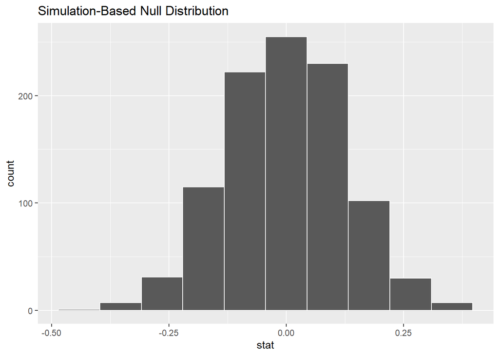

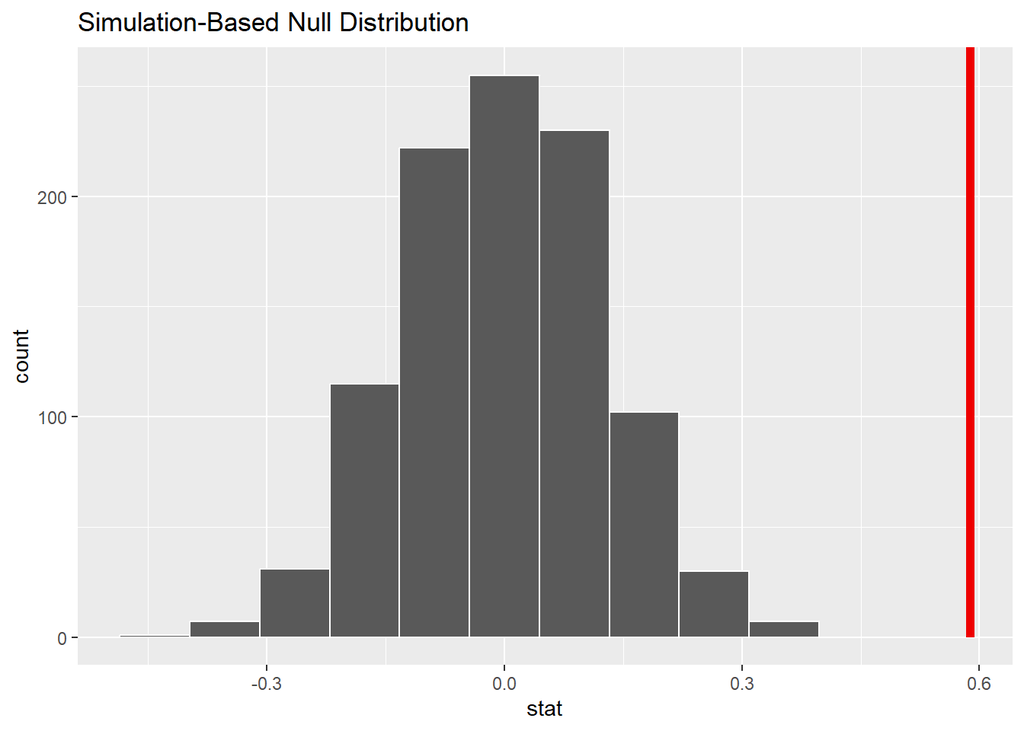

```r
visualize(null_distribution, bins = 10) +
  shade_p_value(obs_stat = obs_diff_means, direction = "right")
```

```r
null_distribution %>%
  get_p_value(obs_stat = obs_diff_means, direction = "right")
```

```
## # A tibble: 1 × 1
##   p_value
##     <dbl>
## 1       0
```

```r
#############################################################################################################
#Year Hypothesis #2

game_year$year = as.character(as.numeric(game_year$year))

null_distribution_2 <- game_year %>%
  specify(formula = rating ~ year) %>%
  hypothesize(null = "independence") %>%
  generate(reps = 1000, type = "permute") %>%
  calculate(stat = "diff in means", order = c(2020,1990))
 null_distribution_2
```

```
## Response: rating (numeric)
## Explanatory: year (factor)
## Null Hypothesis: independence
## # A tibble: 1,000 × 2
##    replicate    stat
##        <int>   <dbl>
##  1         1 -0.275
##  2         2 -0.0796
##  3         3  0.0711
##  4         4 -0.203
##  5         5  0.121
##  6         6 -0.0556
##  7         7 -0.221
##  8         8  0.164
##  9         9  0.0294
## 10        10 -0.173
## # … with 990 more rows
```

```r
 obs_diff_means <- game_year %>%
   specify(rating ~ year) %>%
   calculate(stat = "diff in means", order = c(2020,1990))
 obs_diff_means
```

```
## Response: rating (numeric)
## Explanatory: year (factor)
## # A tibble: 1 × 1
##    stat
##   <dbl>
## 1 0.570
```

```r
 visualize(null_distribution, bins = 10)
```

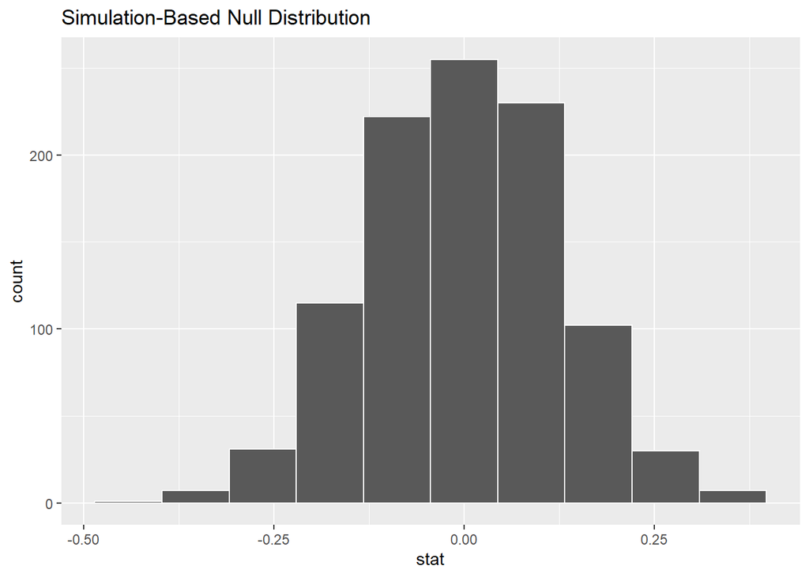

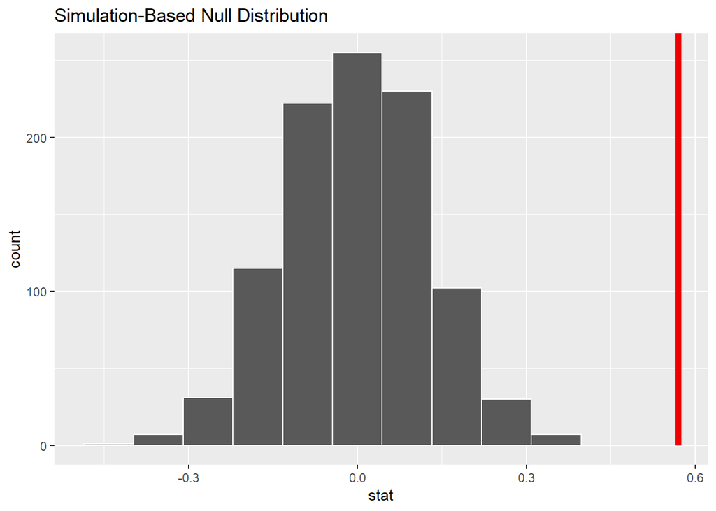

```r
visualize(null_distribution, bins = 10) +
  shade_p_value(obs_stat = obs_diff_means, direction = "right")
```

```r
null_distribution %>%
  get_p_value(obs_stat = obs_diff_means, direction = "right")
```

```
## # A tibble: 1 × 1
##   p_value
##     <dbl>
## 1       0
```

```r
#############################################################################################################

#Descriptive Stats for "Action, Adventure, Drama"
game_fil_drama_dis <- game_fil_drama %>%
  summarize(mean_rating = mean(rating), median_rating = median(rating), Variance_rating = var(rating), standard_deviation_rating = sd(rating))
game_fil_drama_dis
```

```
## # A tibble: 1 × 4
##   mean_rating median_rating Variance_rating standard_deviation_rating
##         <dbl>         <dbl>           <dbl>                     <dbl>
## 1        7.92           7.9           0.972                     0.986
```

```r
#Descriptive Stats for "Action, Adventure, Fantasy"
game_fil_fantasy_dis <- game_fil_fantasy %>%
  summarize(mean_rating = mean(rating), median_rating = median(rating), Variance_rating = var(rating), standard_deviation_rating = sd(rating))
game_fil_fantasy_dis
```

```
## # A tibble: 1 × 4
##   mean_rating median_rating Variance_rating standard_deviation_rating
##         <dbl>         <dbl>           <dbl>                     <dbl>
## 1        7.34           7.6            1.31                      1.14
```

```r
#All Descriptive Stats
game_fil_all_dis <- game_fil %>%
  summarize(mean_rating = mean(rating), median_rating = median(rating), Variance_rating = var(rating), standard_deviation_rating = sd(rating))
game_fil_all_dis
```

```
## # A tibble: 1 × 4
##   mean_rating median_rating Variance_rating standard_deviation_rating
##         <dbl>         <dbl>           <dbl>                     <dbl>
## 1        7.42           7.6            1.30                      1.14
```

```r
###############################################################################################################
#Year Hypothesis
#Descriptive Stats 2010
game_fil_2020_dis <- game_fil_2020 %>%
  summarize(mean_rating = mean(rating), median_rating = median(rating), Variance_rating = var(rating), standard_deviation_rating = sd(rating))
game_fil_2020_dis
```

```
## # A tibble: 1 × 4
##   mean_rating median_rating Variance_rating standard_deviation_rating
##         <dbl>         <dbl>           <dbl>                     <dbl>
## 1        6.95           7.2            1.94                      1.39
```

```r
#Descriptive Stats 1990
game_fil_1990_dis <- game_fil_1990 %>%
  summarize(mean_rating = mean(rating), median_rating = median(rating), Variance_rating = var(rating), standard_deviation_rating = sd(rating))
game_fil_1990_dis
```

```
## # A tibble: 1 × 4
##   mean_rating median_rating Variance_rating standard_deviation_rating
##         <dbl>         <dbl>           <dbl>                     <dbl>
## 1        6.38           6.6            1.36                      1.17
```

> Interpret the results above. [4 points]

### Hypothesis #1

HO: Genre of game has no affect on the rating. We would reject the null hypothesis. HA: The genre of a game has an effect on the rating. We would not reject the alternative hypothesis.

### Hypotheses #2

> Discuss any practical implications of your results. [4 points]

There are many practical uses for this research in terms of video game development and enjoyment. For example, if a new gamer wanted to find out what “era” of video games is “the best,” this research would enlighten them. By understanding that years have an effect on video game ratings, it is clear to see that the newer games (more recent games created or released) would provide a better experience than the ones that have come before. That way, the new gamer will not have to spend hours of time playing video games that are not as enjoyable. With the results I have discovered, it is clear to see that years and time have an effect, and “better” games are created and released as the years increase. Another use for this information would be understanding how genres affect ratings as well. One scenario would be a game developer trying to figure out what genre of game they should make: “action, adventure, drama” or “action, adventure, fantasy.” If their goal is to have a higher rating in terms of the statistical results, picking a specific genre would certainly help their efforts.

> Describe any limitations of your data analyses. [4 points]

With my data analysis, I did notice some limitations. The first limitation that I encountered was how it only “tests” two groups. Since the test could only process two groups, I had to filter the original DF until I had what I desired. The original DF had multiple groups, so I had to limit the amount present in the test. In my imagination, being able to test all genres and groups would have provided a “clearer” picture than just testing two. Another aspect of the results was that while it may tell you if one variable affects another, it does not tell you what specific year or genre is the “best.” That would require a different test. In terms of the year, the same follows. As we may be able to tell that years have an effect on rating, we could only test two groups. which means I had to limit the DF and select two years or groups to test instead of all the years at once. In my opinion, testing all the years would provide a better understanding, but I also do not know if that is possible. While we are able to come to a conclusion (reject or not reject) based on our hypothesis and results, this does not give us an answer as to what specific year was or is the “best.” The analysis is not meant to be a guild on how to create or play video games as it is a cultivation of multiple people’s opinions, so while one genre may be highly rated, it is not a guarantee that the newly created game in that genre will also be highly rated just because it is in the same category.

# Submitting the Project

After you’ve completed all parts of this assignment to your satisfaction, click on the `Knit` button in the toolbar at the top of this pane. When/if prompted, please indicate that you wish to knit to an HTML file. Knitting to PDF or Word are fancy tricks but take some more setting up, and that’s beyond the scope of this class.

After RStudio has finished knitting the file, it will bring it up in a special RStudio interface. You can use this interface to review the document and make sure that everything appears as you want. Then, however, you should navigate to the same folder where you have stored this `.Rmd` file, and you will find a `.html` file with the same name in that same folder. You can open that file to view this in your browser; more importantly, this is the file that you should submit to Canvas to complete this assignment.

I cannot accept any submission of your work besides the knit `.html` file! If you are having trouble knitting, please get in touch with me instead of submitting the `.Rmd` file and hoping it will work instead. It won’t. I don’t have your data, I won’t see your output, and I can’t grade your work without either of those.

Speaking of having your data, though, it would be nice to have access to all the work you’ve done in addition to the `.html` file. Please open GitHub desktop, navigate to your repository for this class, *commit* the changes that you’ve made in completing this project, and *push* those changes to GitHub. I will also ask you to do this if you need any help along the way.